# mideterm_project

jiaying Ning

3/18/2021

###### import package

```r
#load package
library(caret)
library(splines)
library(mgcv)
library(pdp)
library(earth)
library(tidyverse)
library(ggplot2)
library(dplyr)
library(AppliedPredictiveModeling)
library(glmnet)
library(corrplot)
```

###### Fit Data

```r
student_performance = read.csv("./data/student-mat.csv")
```

#### Process and Clean data

Summary output

```r
summary(student_performance)
```

```
##     school              sex                 age         address
##  Length:395         Length:395         Min.   :15.0   Length:395
##  Class :character   Class :character   1st Qu.:16.0   Class :character
##  Mode  :character   Mode  :character   Median :17.0   Mode  :character
##                                        Mean   :16.7
##                                        3rd Qu.:18.0
##                                        Max.   :22.0
##    famsize            Pstatus               Medu            Fedu
##  Length:395         Length:395         Min.   :0.000   Min.   :0.000
##  Class :character   Class :character   1st Qu.:2.000   1st Qu.:2.000
##  Mode  :character   Mode  :character   Median :3.000   Median :2.000
##                                        Mean   :2.749   Mean   :2.522
##                                        3rd Qu.:4.000   3rd Qu.:3.000
##                                        Max.   :4.000   Max.   :4.000
##      Mjob               Fjob              reason            guardian
##  Length:395         Length:395         Length:395         Length:395
##  Class :character   Class :character   Class :character   Class :character
##  Mode  :character   Mode  :character   Mode  :character   Mode  :character
##
##
##
##    traveltime      studytime        failures       schoolsup
##  Min.   :1.000   Min.   :1.000   Min.   :0.0000   Length:395
##  1st Qu.:1.000   1st Qu.:1.000   1st Qu.:0.0000   Class :character
##  Median :1.000   Median :2.000   Median :0.0000   Mode  :character
##  Mean   :1.448   Mean   :2.035   Mean   :0.3342
##  3rd Qu.:2.000   3rd Qu.:2.000   3rd Qu.:0.0000
##  Max.   :4.000   Max.   :4.000   Max.   :3.0000
##     famsup              paid            activities          nursery
##  Length:395         Length:395         Length:395         Length:395
##  Class :character   Class :character   Class :character   Class :character
##  Mode  :character   Mode  :character   Mode  :character   Mode  :character
##
##
##
##     higher            internet           romantic             famrel
##  Length:395         Length:395         Length:395         Min.   :1.000
##  Class :character   Class :character   Class :character   1st Qu.:4.000
##  Mode  :character   Mode  :character   Mode  :character   Median :4.000
##                                                           Mean   :3.944
```

[output cut: 8 more lines]

```
##  Max.   :5.000   Max.   :5.000   Max.   :5.000   Max.   :5.000
##      health         absences            G1              G2
##  Min.   :1.000   Min.   : 0.000   Min.   : 3.00   Min.   : 0.00
##  1st Qu.:3.000   1st Qu.: 0.000   1st Qu.: 8.00   1st Qu.: 9.00
##  Median :4.000   Median : 4.000   Median :11.00   Median :11.00
##  Mean   :3.554   Mean   : 5.709   Mean   :10.91   Mean   :10.71
##  3rd Qu.:5.000   3rd Qu.: 8.000   3rd Qu.:13.00   3rd Qu.:13.00
##  Max.   :5.000   Max.   :75.000   Max.   :19.00   Max.   :19.00
##        G3
##  Min.   : 0.00
##  1st Qu.: 8.00
##  Median :11.00
##  Mean   :10.42
##  3rd Qu.:14.00
##  Max.   :20.00
```

frequency table output

```r
knitr::kable(lapply(student_performance[,1:29], table))
```

| Var1 | Freq |
| --- | --- |
| GP | 349 |
| MS | 46 |

| Var1 | Freq |
| --- | --- |
| F | 208 |
| M | 187 |

| Var1 | Freq |
| --- | --- |
| 15 | 82 |
| 16 | 104 |
| 17 | 98 |
| 18 | 82 |
| 19 | 24 |
| 20 | 3 |
| 21 | 1 |
| 22 | 1 |

| Var1 | Freq |
| --- | --- |
| R | 88 |
| U | 307 |

| Var1 | Freq |
| --- | --- |
| GT3 | 281 |
| LE3 | 114 |

| Var1 | Freq |
| --- | --- |
| A | 41 |
| T | 354 |

| Var1 | Freq |
| --- | --- |
| 0 | 3 |
| 1 | 59 |
| 2 | 103 |
| 3 | 99 |
| 4 | 131 |

| Var1 | Freq |
| --- | --- |
| 0 | 2 |
| 1 | 82 |
| 2 | 115 |
| 3 | 100 |
| 4 | 96 |

| Var1 | Freq |
| --- | --- |
| at_home | 59 |
| health | 34 |
| other | 141 |
| services | 103 |
| teacher | 58 |

| Var1 | Freq |
| --- | --- |
| at_home | 20 |
| health | 18 |
| other | 217 |
| services | 111 |
| teacher | 29 |

| Var1 | Freq |
| --- | --- |
| course | 145 |
| home | 109 |
| other | 36 |
| reputation | 105 |

| Var1 | Freq |
| --- | --- |
| father | 90 |
| mother | 273 |
| other | 32 |

| Var1 | Freq |
| --- | --- |
| 1 | 257 |
| 2 | 107 |
| 3 | 23 |
| 4 | 8 |

| Var1 | Freq |
| --- | --- |
| 1 | 105 |
| 2 | 198 |
| 3 | 65 |
| 4 | 27 |

| Var1 | Freq |
| --- | --- |
| 0 | 312 |
| 1 | 50 |
| 2 | 17 |
| 3 | 16 |

| Var1 | Freq |
| --- | --- |
| no | 344 |
| yes | 51 |

| Var1 | Freq |
| --- | --- |
| no | 153 |
| yes | 242 |

| Var1 | Freq |
| --- | --- |
| no | 214 |
| yes | 181 |

| Var1 | Freq |
| --- | --- |
| no | 194 |
| yes | 201 |

| Var1 | Freq |
| --- | --- |
| no | 81 |
| yes | 314 |

| Var1 | Freq |
| --- | --- |
| no | 20 |
| yes | 375 |

| Var1 | Freq |
| --- | --- |
| no | 66 |
| yes | 329 |

| Var1 | Freq |
| --- | --- |
| no | 263 |
| yes | 132 |

| Var1 | Freq |
| --- | --- |
| 1 | 8 |
| 2 | 18 |
| 3 | 68 |
| 4 | 195 |
| 5 | 106 |

| Var1 | Freq |
| --- | --- |
| 1 | 19 |
| 2 | 64 |
| 3 | 157 |
| 4 | 115 |
| 5 | 40 |

| Var1 | Freq |
| --- | --- |
| 1 | 23 |
| 2 | 103 |
| 3 | 130 |
| 4 | 86 |
| 5 | 53 |

| Var1 | Freq |
| --- | --- |
| 1 | 276 |
| 2 | 75 |
| 3 | 26 |
| 4 | 9 |
| 5 | 9 |

| Var1 | Freq |
| --- | --- |
| 1 | 151 |
| 2 | 85 |
| 3 | 80 |
| 4 | 51 |
| 5 | 28 |

| Var1 | Freq |
| --- | --- |
| 1 | 47 |
| 2 | 45 |
| 3 | 91 |
| 4 | 66 |
| 5 | 146 |

spaghetti plot:

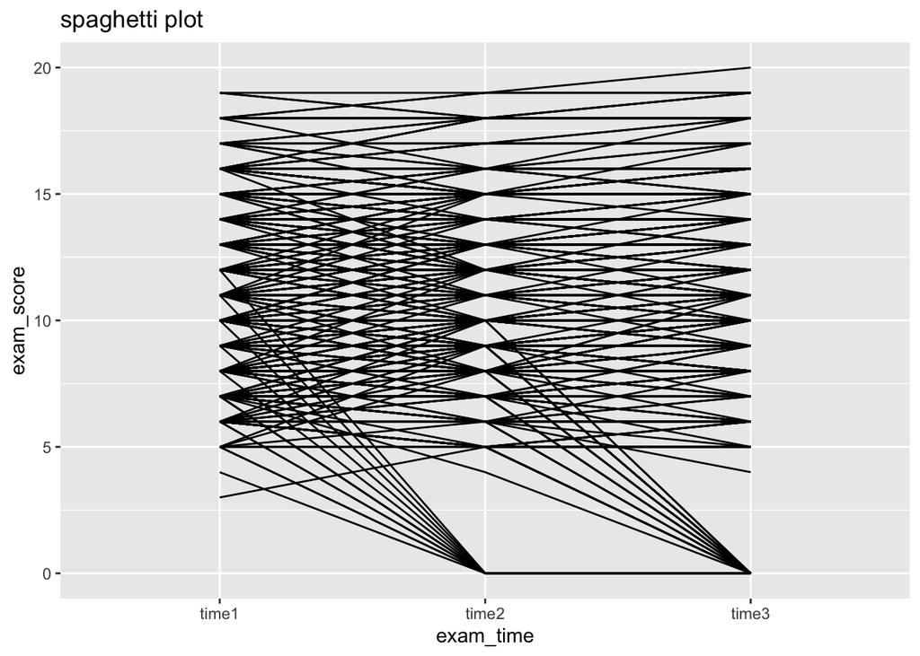

```r
student_longititude %>%
  ggplot( aes(exam_time, exam_score, group=id)) + geom_line() +   labs(title = "spaghetti plot")
```

filter out those who have 0 values in exam2 and exam3

```r
student_longititude %>%
  filter(exam_time != "time1" & exam_score == 0 )
```

| exam_time | exam_score | id | school | sex | age | address | famsize | pstatus | medu | fedu | mjob | fjob | reason | guardian | traveltime | studytime | failures | schoolsup | famsup | paid | activities | nursery | higher | internet | romantic | famrel | freetime | goout | dalc | … |
| --- | --- | --- | --- | --- | --- | --- | --- | --- | --- | --- | --- | --- | --- | --- | --- | --- | --- | --- | --- | --- | --- | --- | --- | --- | --- | --- | --- | --- | --- | --- |
| time3 | 0 | 129 | GP | M | 18 | R | GT3 | T | 2 | 2 | services | other | reputation | mother | 1 | 1 | 2 | no | yes | no | yes | yes | yes | yes | no | 3 | 3 | 3 | 1 | … |
| time2 | 0 | 131 | GP | F | 15 | R | GT3 | T | 3 | 4 | services | teacher | course | father | 2 | 3 | 2 | no | yes | no | no | yes | yes | yes | yes | 4 | 2 | 2 | 2 | … |
| time3 | 0 | 131 | GP | F | 15 | R | GT3 | T | 3 | 4 | services | teacher | course | father | 2 | 3 | 2 | no | yes | no | no | yes | yes | yes | yes | 4 | 2 | 2 | 2 | … |
| time2 | 0 | 132 | GP | F | 15 | U | GT3 | T | 1 | 1 | at_home | other | course | mother | 3 | 1 | 0 | no | yes | no | yes | no | yes | yes | yes | 4 | 3 | 3 | 1 | … |
| time3 | 0 | 132 | GP | F | 15 | U | GT3 | T | 1 | 1 | at_home | other | course | mother | 3 | 1 | 0 | no | yes | no | yes | no | yes | yes | yes | 4 | 3 | 3 | 1 | … |
| time2 | 0 | 135 | GP | M | 15 | R | GT3 | T | 3 | 4 | at_home | teacher | course | mother | 4 | 2 | 0 | no | yes | no | no | yes | yes | no | yes | 5 | 3 | 3 | 1 | … |
| time3 | 0 | 135 | GP | M | 15 | R | GT3 | T | 3 | 4 | at_home | teacher | course | mother | 4 | 2 | 0 | no | yes | no | no | yes | yes | no | yes | 5 | 3 | 3 | 1 | … |
| time2 | 0 | 136 | GP | F | 15 | U | GT3 | T | 4 | 4 | services | at_home | course | mother | 1 | 3 | 0 | no | yes | no | yes | yes | yes | yes | yes | 4 | 3 | 3 | 1 | … |
| time3 | 0 | 136 | GP | F | 15 | U | GT3 | T | 4 | 4 | services | at_home | course | mother | 1 | 3 | 0 | no | yes | no | yes | yes | yes | yes | yes | 4 | 3 | 3 | 1 | … |
| time2 | 0 | 137 | GP | M | 17 | R | GT3 | T | 3 | 4 | at_home | other | course | mother | 3 | 2 | 0 | no | no | no | no | yes | yes | no | no | 5 | 4 | 5 | 2 | … |

[output cut: 41 more lines]

- A strange pattern I notice from the current data is that, there seems to be a group of students who continue to have 0 scores for both period2 and period3 exam, while there is a gap between scores 0 and 5. A potential explanation is that some students decide to drop the course after the first or second exam.
- In this case I decide to keep these strange 0 values since I cannot make conclusion about what these 0 value truly mean.

#### create data frame that contain average score

```r
student_avgexam =
  student_performance %>%
  janitor::clean_names() %>%
  na.omit() %>%
  mutate(avgscore = (g1+g2+g3)/3)%>%
  dplyr::select(-g1,-g2,-g3)
```

distribution of outcome:

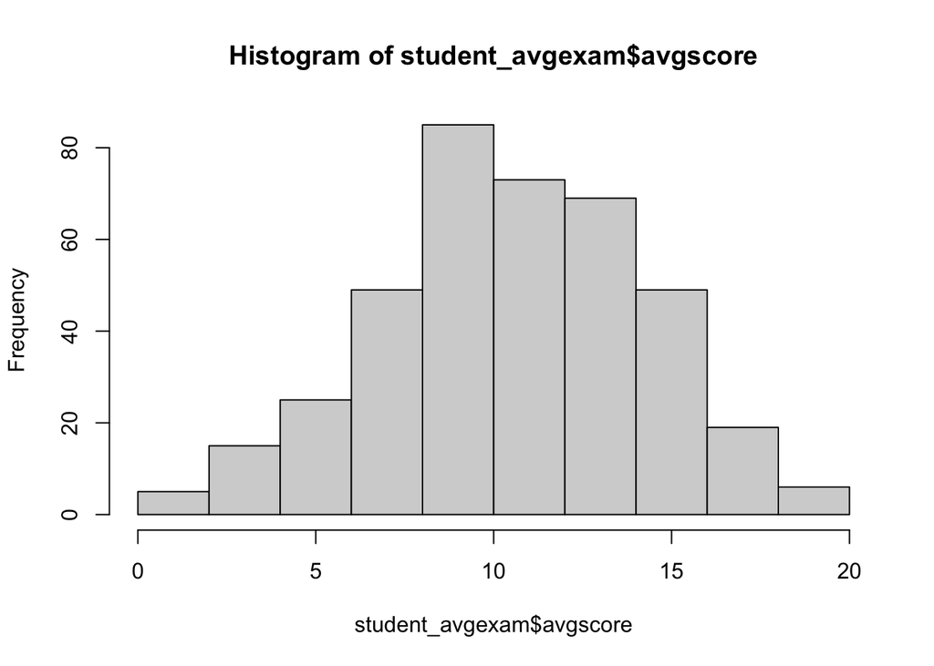

```r
hist(student_avgexam$avgscore)
```

Since the outcome of interest is approximately normal, transformation is not required in this case.

#### splitting the data into training and testing

```r
rowTrain <- createDataPartition(y = student_avgexam$avgscore,
                                p = 0.75,
                                list = FALSE)
training = student_avgexam[rowTrain,]
testing = student_avgexam[-rowTrain,]

training2 <- model.matrix(avgscore ~ ., training)[ ,-1]
test2 = model.matrix(avgscore ~ ., testing)[ ,-1]
y <- training$avgscore
```

#### Exploratory data analysis

1. correlation plot

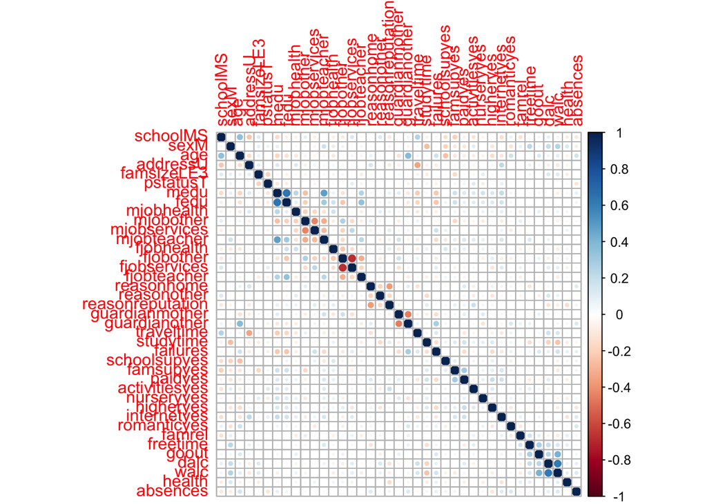

```r
corrplot::corrplot(cor(training2), method = "circle", type = "full")
```

We can see that overall most predictors do not have strong correlation with other predictors, but some correlation does exist,for example:

- medu and fedu seem to have positive correlation.
- fjobservice and fjobother seem to have strong negative correlation,
- freetime, goout, Dalc(workday alcohol consumption), Walc(weekend alcohol consumption) seems to be positively correlated.

Collinearity is a potential problem for models that have a relatively large number of predictors, and collinearity can lead to large variance. we may regularize the coefficient to control the variance by using ridge and lasso.

2. scatterplot

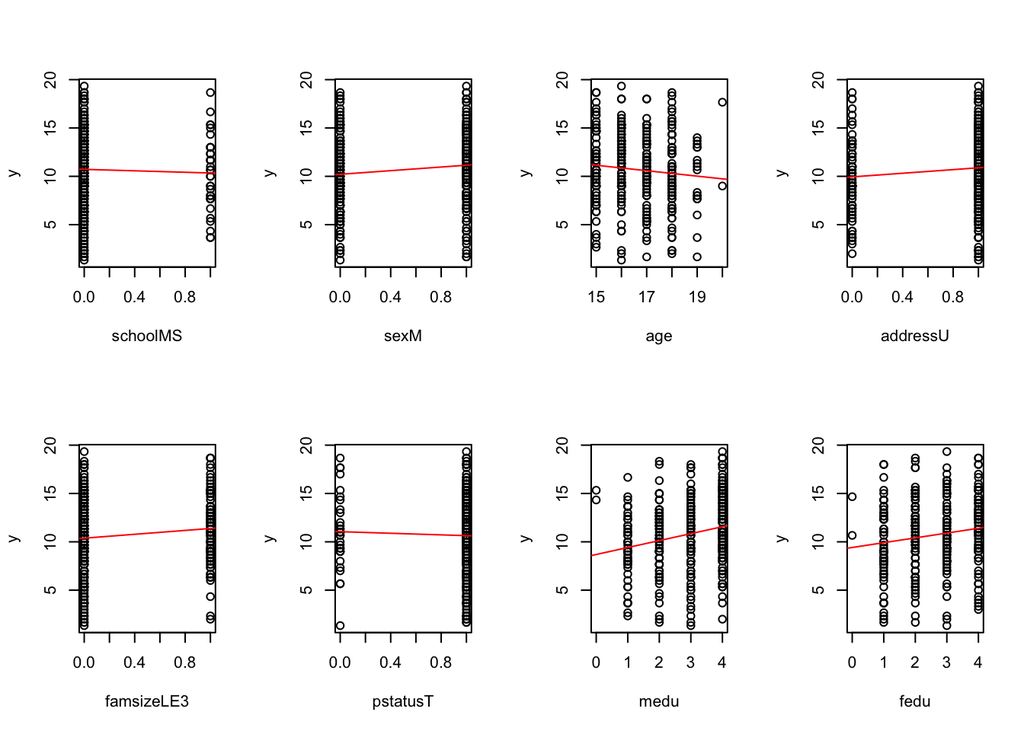

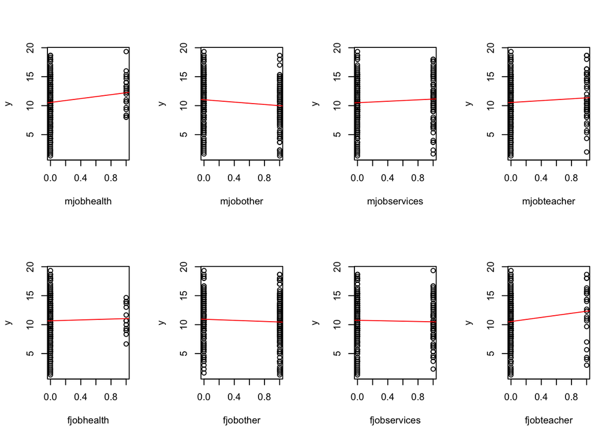

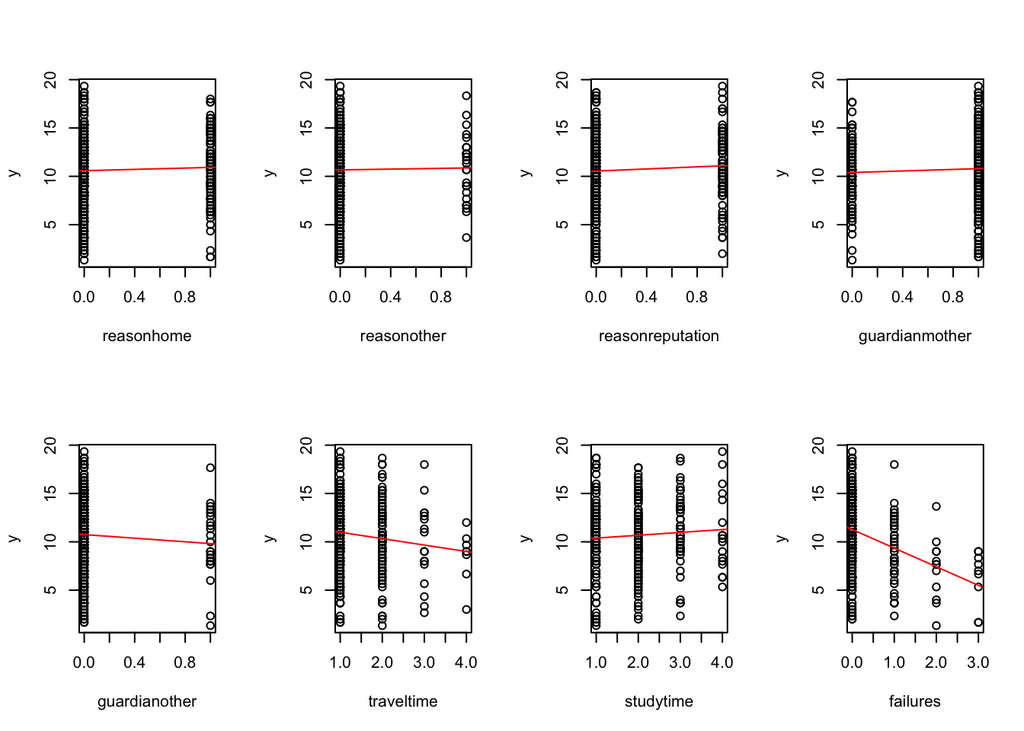

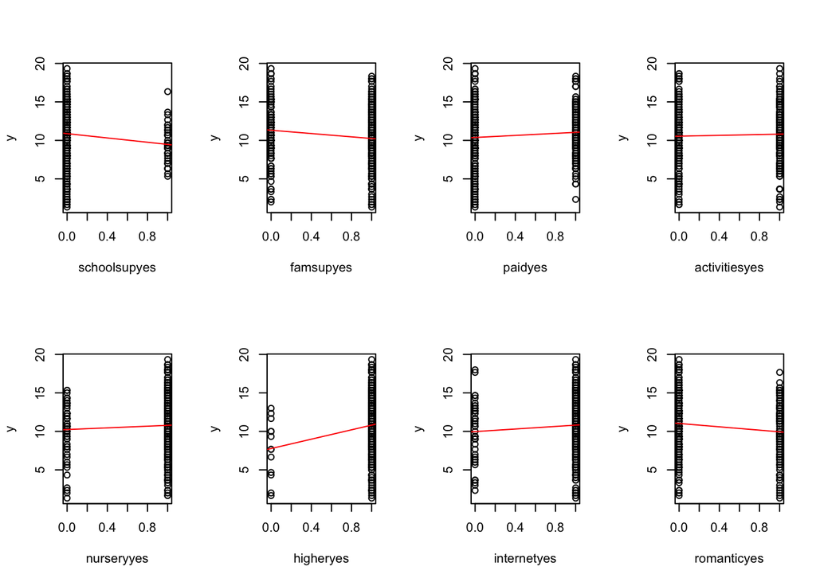

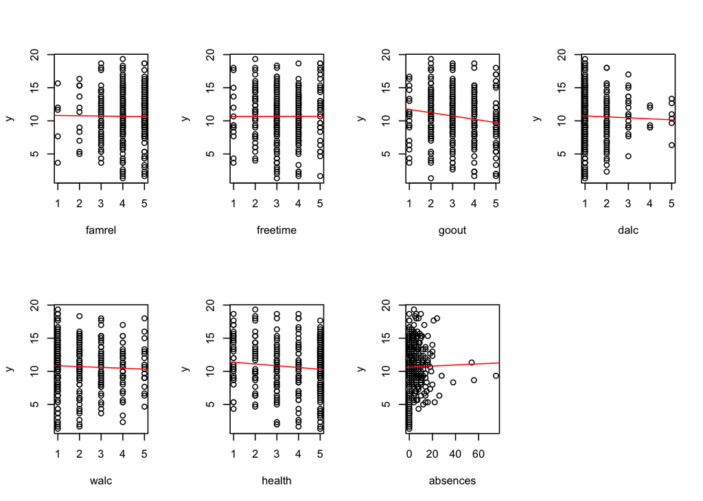

```r
par(mfrow=c(2,4))
for(i in 1:39)
{    plot(training2[,i], y, xlab = colnames(training2)[i], ylab="y")
    abline(lm(y~(training2)[,i]), col="red") }
```

#### Linear Model

```r
LinearMod <- lm(avgscore ~ .,
data = training)

summary(LinearMod)
```

```
##
## Call:
## lm(formula = avgscore ~ ., data = training)
##
## Residuals:
##     Min      1Q  Median      3Q     Max
## -9.1740 -2.1200  0.2528  2.1965  7.0964
##
## Coefficients:
##                  Estimate Std. Error t value Pr(>|t|)
## (Intercept)      12.98201    4.15814   3.122  0.00200 **
## schoolMS          0.12442    0.75216   0.165  0.86875
## sexM              0.93933    0.45772   2.052  0.04116 *
## age              -0.22194    0.20165  -1.101  0.27208
## addressU          0.09747    0.54927   0.177  0.85929
## famsizeLE3        0.79091    0.45402   1.742  0.08270 .
## pstatusT          0.09227    0.66081   0.140  0.88906
## medu              0.42606    0.30064   1.417  0.15764
## fedu             -0.20842    0.26125  -0.798  0.42573
## mjobhealth        0.90757    1.06795   0.850  0.39621
## mjobother        -0.71184    0.66916  -1.064  0.28843
## mjobservices      0.65281    0.73846   0.884  0.37751
## mjobteacher      -1.08792    0.95504  -1.139  0.25571
## fjobhealth       -0.05616    1.27037  -0.044  0.96477
## fjobother        -1.37881    0.90656  -1.521  0.12951
## fjobservices     -1.31348    0.93390  -1.406  0.16080
## fjobteacher       1.25572    1.13655   1.105  0.27025
## reasonhome        0.49900    0.50848   0.981  0.32734
## reasonother       0.31176    0.77571   0.402  0.68809
## reasonreputation  0.48552    0.53483   0.908  0.36483
## guardianmother    0.51167    0.51964   0.985  0.32570
## guardianother     1.52573    0.94714   1.611  0.10843
## traveltime       -0.14714    0.31151  -0.472  0.63708
## studytime         0.44561    0.27111   1.644  0.10147
## failures         -1.78342    0.32337  -5.515 8.46e-08 ***
## schoolsupyes     -1.72878    0.60168  -2.873  0.00440 **
## famsupyes        -1.43837    0.44297  -3.247  0.00132 **
## paidyes           0.23751    0.44783   0.530  0.59631
## activitiesyes     0.03171    0.41286   0.077  0.93883
## nurseryyes        0.24063    0.51085   0.471  0.63800
## higheryes         1.85968    1.02194   1.820  0.06995 .
## internetyes       0.38122    0.58699   0.649  0.51662
## romanticyes      -1.00182    0.44247  -2.264  0.02440 *
## famrel            0.08542    0.23571   0.362  0.71735
## freetime          0.18922    0.21806   0.868  0.38634
## goout            -0.56769    0.20606  -2.755  0.00629 **
## dalc             -0.18515    0.30800  -0.601  0.54826
## walc              0.30370    0.22598   1.344  0.18016
## health           -0.19306    0.14957  -1.291  0.19793
## absences          0.04010    0.02582   1.553  0.12165
## ---
## Signif. codes:  0 '***' 0.001 '**' 0.01 '*' 0.05 '.' 0.1 ' ' 1
##
## Residual standard error: 3.27 on 258 degrees of freedom
## Multiple R-squared:  0.3441, Adjusted R-squared:  0.2449
## F-statistic:  3.47 on 39 and 258 DF,  p-value: 1.317e-09
```

The adjusted R-square is 0.25 which is relatively low since it implies that only 25% of the variablity in average score is explained by the current model.

test error

```r
pred_lm <- predict(LinearMod, testing)
mean((testing$avgscore - pred_lm)^2)
```

```
## [1] 11.60091
```

#### Ridge REGRESSION

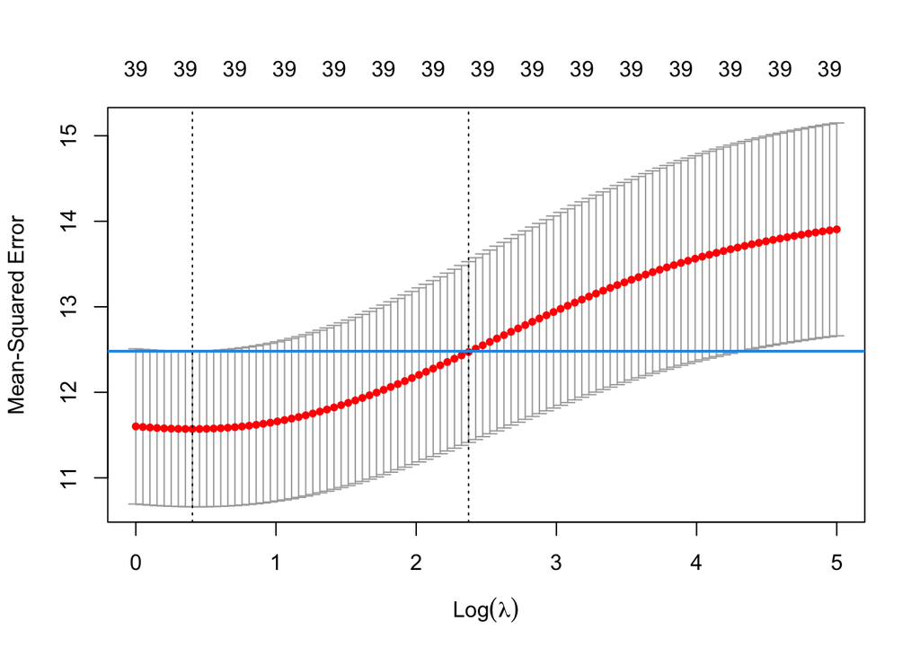

```r
set.seed(2761)
cv.ridge <- cv.glmnet(training2, y,
alpha = 0,
lambda = exp(seq(0, 5, length = 100)))
plot(cv.ridge)
abline(h = (cv.ridge$cvm + cv.ridge$cvsd)[which.min(cv.ridge$cvm)], col = 4, lwd = 2)
```

choosing the best lambda

```r
# min CV MSE
cv.ridge$lambda.min
```

```
## [1] 1.497864
```

```r
# the 1SE rule
cv.ridge$lambda.1se
```

```
## [1] 10.73745
```

```r
ridge_coe=predict(cv.ridge, s = "lambda.min", type = "coefficients")
```

plot: coefficient value versus lambda value

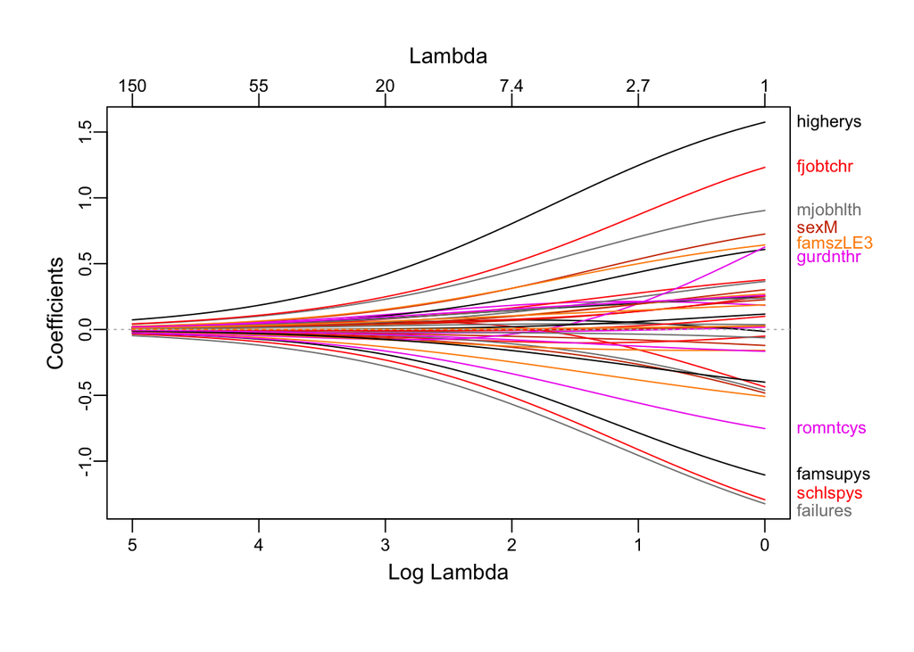

```r
plot_glmnet(cv.ridge$glmnet.fit)
```

Other important feature include:

- positive coefficient:
  - fjobteacher ( father’s job as ‘teacher’))
  - famsizeL3 (family size less or equal to 3)
  - mjobhealth ( mother’s job ‘health’ care related,)
  - sexM (student’s sex: male))
  - guardianother ( student’s guardian: other)
- negetive coefficient:
  - failures ( number of past class failures )
  - famsupyes (family educational support:yes)
  - romanticyes ( with a romantic relationshipLyes)

test error

```r
# make prediction
ridge_pred=(predict(cv.ridge, newx = test2,
s = "lambda.min", type = "response"))
mean((ridge_pred - testing$avgscore)^2)
```

```
## [1] 9.654346
```

#### LASSO REGRESSION

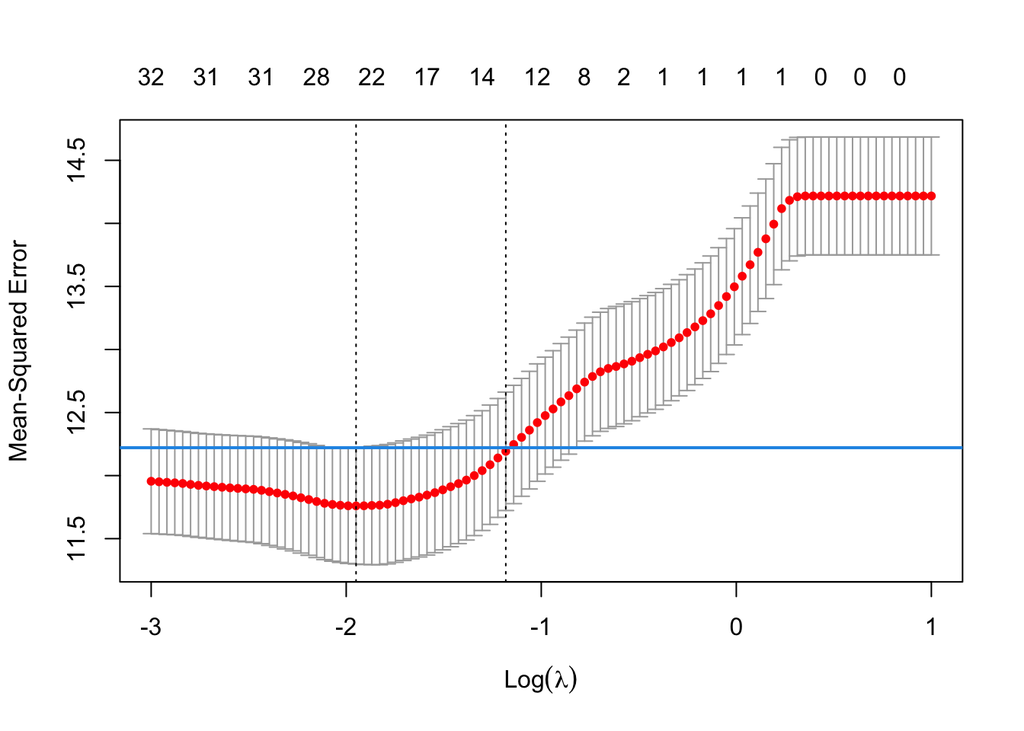

```r
cv.lasso <- cv.glmnet(training2, y,
alpha = 1,
lambda = exp(seq(-3, 1, length = 100)))
plot(cv.lasso)
abline(h = (cv.lasso$cvm + cv.lasso$cvsd)[which.min(cv.lasso$cvm)], col = 4, lwd = 2)
```

chossing the best lambda

```r
cv.lasso$lambda.min
```

```
## [1] 0.1423459
```

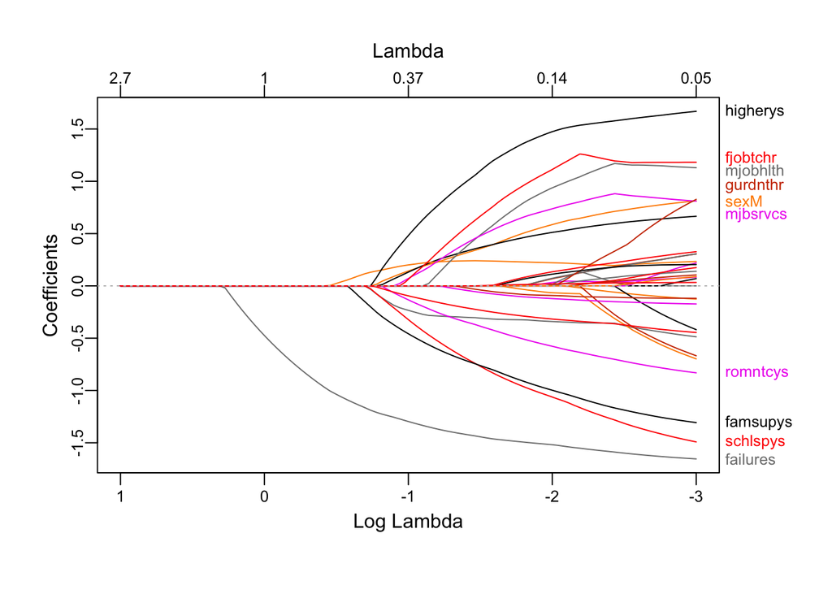

```r
plot_glmnet(cv.lasso$glmnet.fit)
```

```r
Lasso_coe=predict(cv.lasso, s = "lambda.min", type = "coefficients")
```

produce the coefficient that is not regularize into 0

```r
which(Lasso_coe[,1] != 0)
```

```
##      (Intercept)             sexM         addressU       famsizeLE3
##                1                3                5                6
##             medu       mjobhealth        mjobother     mjobservices
##                8               10               11               12
##        fjobother      fjobteacher       reasonhome reasonreputation
##               15               17               18               20
##       traveltime        studytime         failures     schoolsupyes
##               23               24               25               26
##        famsupyes          paidyes        higheryes      romanticyes
##               27               28               31               33
##            goout           health         absences
##               36               39               40
```

test error

```r
Lasso_pred=predict(cv.lasso, newx = test2, s = "lambda.min", type = "response")
mean((Lasso_pred - testing$avgscore)^2)
```

```
## [1] 9.790941
```

#### comparing coefficient

```r
round(cbind(OLS = coef(LinearMod),
          ridge = ridge_coe,
          lasso=Lasso_coe),4)
```

```
## 40 x 3 sparse Matrix of class "dgCMatrix"
##                      OLS       1       1
## (Intercept)      12.9820 11.1777 10.4893
## schoolMS          0.1244  0.0069  .
## sexM              0.9393  0.6567  0.5669
## age              -0.2219 -0.1024  .
## addressU          0.0975  0.2007  0.0236
## famsizeLE3        0.7909  0.5926  0.4996
## pstatusT          0.0923 -0.0740  .
## medu              0.4261  0.2301  0.2231
## fedu             -0.2084  0.0167  .
## mjobhealth        0.9076  0.8375  0.9049
## mjobother        -0.7118 -0.4614 -0.3373
## mjobservices      0.6528  0.5482  0.7177
## mjobteacher      -1.0879 -0.3156  .
## fjobhealth       -0.0562  0.1950  .
## fjobother        -1.3788 -0.3833 -0.0596
## fjobservices     -1.3135 -0.3639  .
## fjobteacher       1.2557  1.1003  1.0759
## reasonhome        0.4990  0.3204  0.0523
## reasonother       0.3118  0.2435  .
## reasonreputation  0.4855  0.3411  0.0562
## guardianmother    0.5117  0.2003  .
## guardianother     1.5257  0.4397  .
## traveltime       -0.1471 -0.1585 -0.0901
## studytime         0.4456  0.2595  0.1218
## failures         -1.7834 -1.1864 -1.5123
## schoolsupyes     -1.7288 -1.1519 -1.0385
## famsupyes        -1.4384 -0.9887 -0.9776
## paidyes           0.2375  0.2291  0.1015
## activitiesyes     0.0317  0.0397  .
## nurseryyes        0.2406  0.1711  .
## higheryes         1.8597  1.4629  1.4492
## internetyes       0.3812  0.2383  .
## romanticyes      -1.0018 -0.6814 -0.5611
## famrel            0.0854  0.0179  .
## freetime          0.1892  0.0944  .
## goout            -0.5677 -0.3538 -0.3106
## dalc             -0.1852 -0.0489  .
## walc              0.3037  0.0676  .
## health           -0.1931 -0.1519 -0.1174
## absences          0.0401  0.0222  0.0173
```

#### Comparing different models CV RMSE

```r
ctrl1 <- trainControl(method = "repeatedcv", number = 10, repeats = 5)

set.seed(2)
lm.fit <- train(training2, y,
                method = "lm",
                trControl = ctrl1)


lasso.fit <- train(training2, y,
                   method = "glmnet",
                   tuneGrid = expand.grid(alpha = 1,
                                          lambda = exp(seq(-3, 1, ength=100))),
                   trControl = ctrl1)
ridge.fit <- train(training2, y,
                   method = "glmnet",
                   tuneGrid = expand.grid(alpha = 0,
                                          lambda = exp(seq(0, 5, length=100))),
                   # preProc = c("center", "scale"),
                   trControl = ctrl1)

resamp <- resamples(list(lasso = lasso.fit, ridge = ridge.fit, lm = lm.fit))
summary(resamp)
```

```
##
## Call:
## summary.resamples(object = resamp)
##
## Models: lasso, ridge, lm
## Number of resamples: 50
##
## MAE
##           Min.  1st Qu.   Median     Mean  3rd Qu.     Max. NA's
## lasso 2.161167 2.508079 2.737588 2.742060 2.925457 3.524771    0
## ridge 1.938691 2.576133 2.714473 2.721475 2.903401 3.369606    0
## lm    2.097544 2.625500 2.758633 2.806362 2.968400 3.926747    0
##
## RMSE
##           Min.  1st Qu.   Median     Mean  3rd Qu.     Max. NA's
## lasso 2.556550 3.212601 3.529699 3.448873 3.698733 4.237159    0
## ridge 2.646426 3.192177 3.463336 3.395146 3.615038 4.193731    0
## lm    2.764957 3.270868 3.489813 3.505014 3.713164 4.702624    0
##
## Rsquared
##              Min.    1st Qu.    Median      Mean   3rd Qu.      Max. NA's
## lasso 0.006734694 0.09026599 0.1729205 0.1790420 0.2346169 0.4326880    0
## ridge 0.019407628 0.10605910 0.1831072 0.2029576 0.2938699 0.6019540    0
## lm    0.001605268 0.11560100 0.2054468 0.1991474 0.2663925 0.4894342    0
```

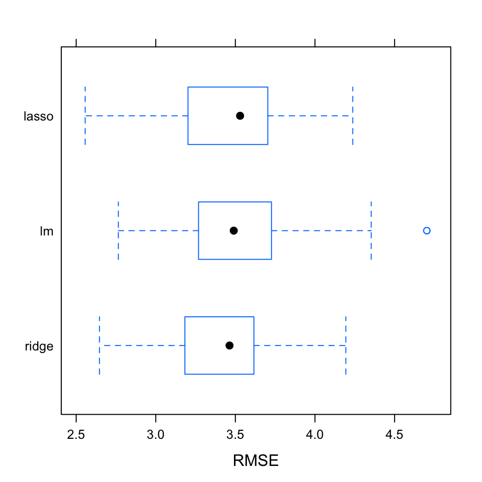

```r
bwplot(resamp, metric = "RMSE")
```

- When I compare the cross-validation RMSE between lm, lasso, and ridge regression model, we see that ridge model actually have lower RMSE mean and overall lower RMSE value comparing to lasso and lm. Lower RMSE means that the model have relatively smaller noise and was able to account for important features.